# Boosting

Mats Hansson

17 oktober 2016

### Boosting

These methods use trees as building blocks to build more complex models. Here we will use the Boston Houseing data to explore boosting. These data are in the `MASS`packages. It gives housing values others statistics in each of 506 suburbs of Boston based on a 1970 census.

Boosting is a machine learning ensemble meta-algorithm for primarily reducing bias, and a family of machine learning algorithms which convert weak learners to strong ones.

Lets load the packages and create a training data.

```r
library(ISLR)
library(gbm)
library(MASS)

set.seed(101)

train=sample(1:nrow(Boston),300)
```

Boosting builds lots of smaller trees. Unlike random forests, each new tree in boosting tries to patch up the deficiencies of the current ensamble.

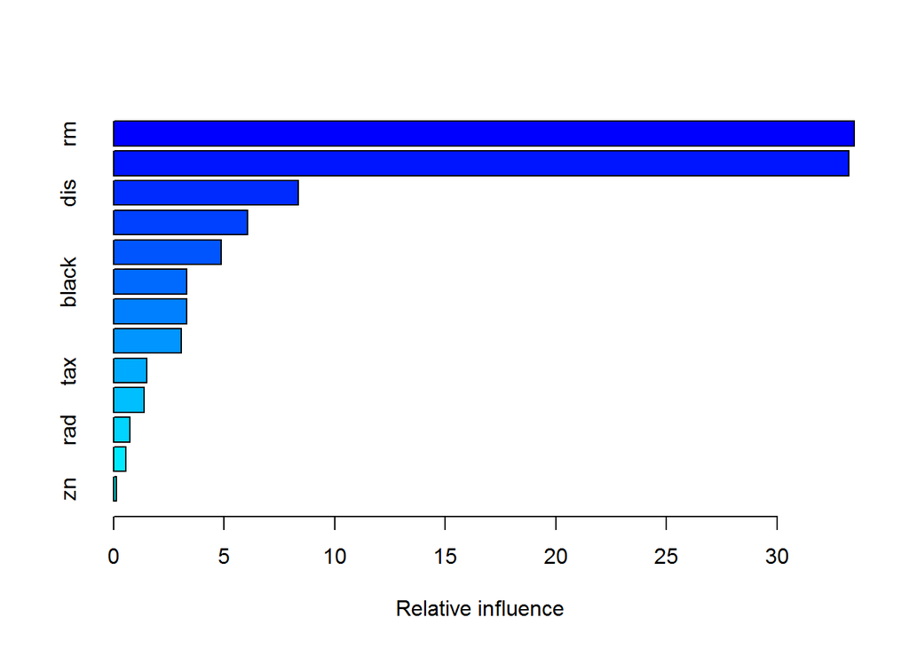

```
##             var    rel.inf
## rm           rm 33.4858251
## lstat     lstat 33.2567329
## dis         dis  8.3591410
## crim       crim  6.0449106
## nox         nox  4.8699097
## black     black  3.3197609
## ptratio ptratio  3.3162724
## age         age  3.0673985
## tax         tax  1.5049077
## chas       chas  1.3903596
## rad         rad  0.7237600
## indus     indus  0.5471690
## zn           zn  0.1138526
```

```r
boost.boston=gbm(medv~.,data=Boston[train,], distribution="gaussian", n.trees=10000,
    shrinkage=0.01, interaction.depth=4)
summary(boost.boston)
```

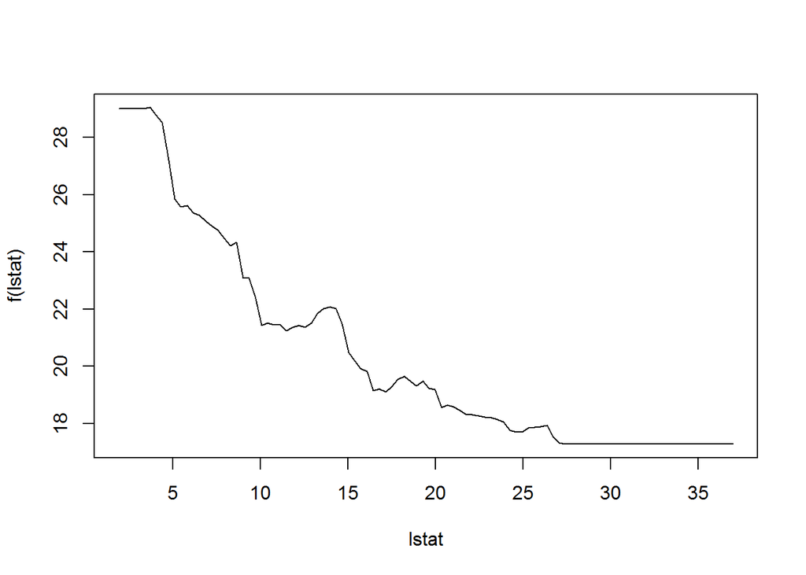

```r
plot(boost.boston, i="lstat")
```

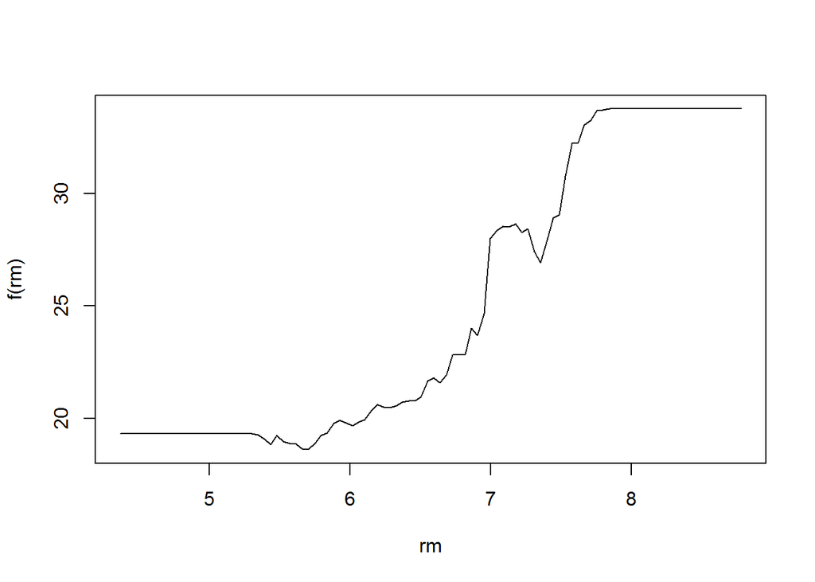

```r
plot(boost.boston, i="rm")
```

Lets make a prediction on the test set. With boosting, the number of trees is a tuning parameter, and if we have too many we can overfit. So we should use cross-validation to select the numver if trees. Instead, we will compute the test error as a function of the numver of trees, and make a plot.

```r
n.trees=seq(from=100, to=20000, by=100)
predmat=predict(boost.boston, newdata=Boston[-train,], n.trees=n.trees)
```

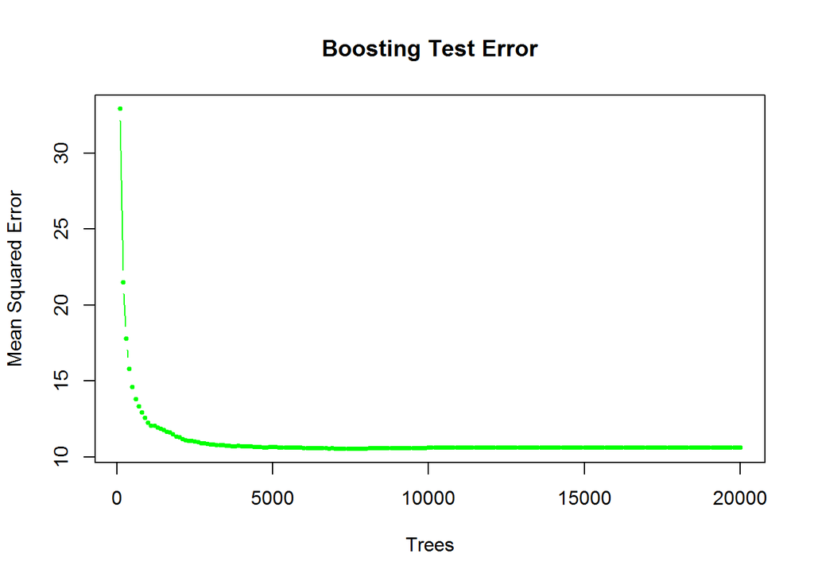

```r
## dim(predmat)
berr=with(Boston[-train,], apply((predmat-medv)^2,2,mean))
plot(n.trees, berr, pch=19, ylab="Mean Squared Error", xlab="Trees",
    main="Boosting Test Error", cex=0.5, type="b", col="green")
```

Comparing different interaction.

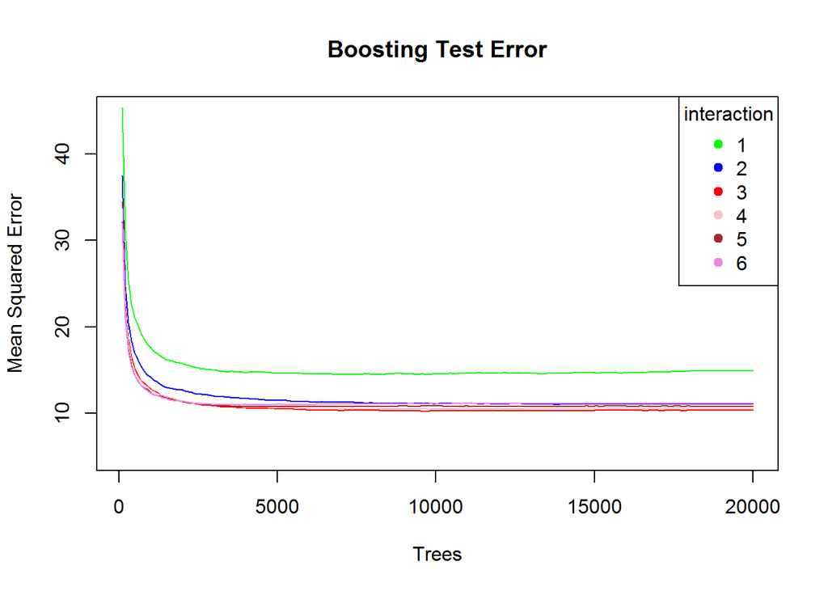

```r
berrmat=matrix(NA, length(n.trees), 6)

for (i in 1:6) {
boost.boston=gbm(medv~.,data=Boston[train,], distribution="gaussian", n.trees=20000,
    shrinkage=0.01, interaction.depth=i)
  predmat=predict(boost.boston, newdata=Boston[-train,], n.trees=n.trees)
  berrmat[,i]=with(Boston[-train,], apply((predmat-medv)^2,2,mean))
}

plot(n.trees, berrmat[,1], pch=19, ylab="Mean Squared Error", xlab="Trees",
    main="Boosting Test Error", cex=1, type="l", col="green", ylim=c(5,45))
lines(n.trees, berrmat[,2], cex=1, type="l", col="blue")
lines(n.trees, berrmat[,3], cex=1, type="l", col="red")
lines(n.trees, berrmat[,4], cex=1, type="l", col="pink")
lines(n.trees, berrmat[,5], cex=1, type="l", col="brown")
lines(n.trees, berrmat[,6], cex=1, type="l", col="violet")



legend("topright",title="interaction", legend=c("1", "2","3","4","5","6"), pch=19,
       col=c("green", "blue","red","pink","brown","violet"))
```

```r
apply(berrmat, 2, mean)
```

```
## [1] 15.25202 11.74979 10.81997 10.99379 11.15588 11.38878
```

```r
apply(berrmat, 2, mean)
```

```
## [1] 15.25202 11.74979 10.81997 10.99379 11.15588 11.38878
```